# Opal Reporting with R

This is an example of how to use **knitr** for producing reports on data stored in [Opal](http://wiki.obiba.org/display/OPALDOC).

### Procedure

The requirement on client side is to have **opal** package installed:

```r
install.packages('opal', repos=c(getOption('repos'), 'http://cran.obiba.org'), dependencies=TRUE)
```

The requirements on server side is:

- to have permissions to access to Opal data
- to have permission to send R commands to Opal server
- to have a running R server

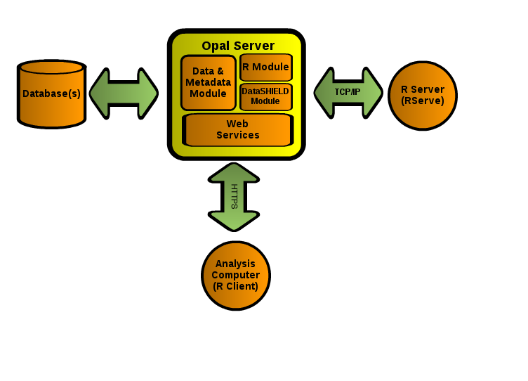

The procedure is then the following:

- connect to Opal server
- assign data from Opal to the associated R server
- send to Opal R commands to be executed in R server
- process in R client the data received from these commands

### Example

#### Opal Login

Load the required libraries on client side and login in Opal (credentials and output are hidden)…

#### Data Assignment

Assign some variables into a data.frame with associated *D* symbol in R on Opal server side:

```r
opal.assign(o,'D','FNAC.FNAC',variables=c('SVUOSI','SUKUP','PITUUS','PAINO'))
```

Preview the assigned data.frame:

```r
opal.execute(o,'head(D)')
```

```
##                     SVUOSI SUKUP   PITUUS    PAINO
## 1000502517535681229   1956     2 1.717730 50.59579
## 1007286407843912597   1972     1 1.625143 68.66697
## 1007294810171882184   1975     2 1.690857 77.92537
## 1008306342245432754   1958     1 1.666475 78.29238
## 1008983561370747969   1960     1 1.661418 87.71623
## 1011258566350785406   1969     2 1.744092 55.51250
```

Summary of the assigned data.frame:

```r
opal.execute(o,'summary(D)')
```

```
##      SVUOSI     SUKUP        PITUUS          PAINO
##  Min.   :1933   1:1512   Min.   :1.372   Min.   : 40.10
##  1st Qu.:1944   2:1488   1st Qu.:1.624   1st Qu.: 67.08
##  Median :1957            Median :1.683   Median : 77.40
##  Mean   :1957            Mean   :1.684   Mean   : 77.87
##  3rd Qu.:1970            3rd Qu.:1.747   3rd Qu.: 88.74
##  Max.   :1982            Max.   :2.009   Max.   :137.41
```

#### Data Plots

Histogram figure of the *PITUUS* variable:

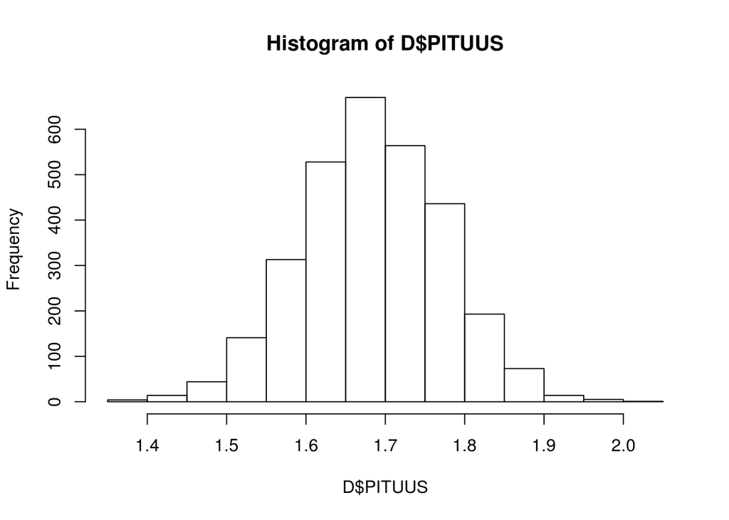

```r
plot(opal.execute(o,'hist(D$PITUUS)'))
```

Loading *ggplot2* library in R on Opal server side… This will fail if *ggplot2* is not installed in R server environment.

Plot *PITUUS* vs. *PAINO* with “lm” smoothing:

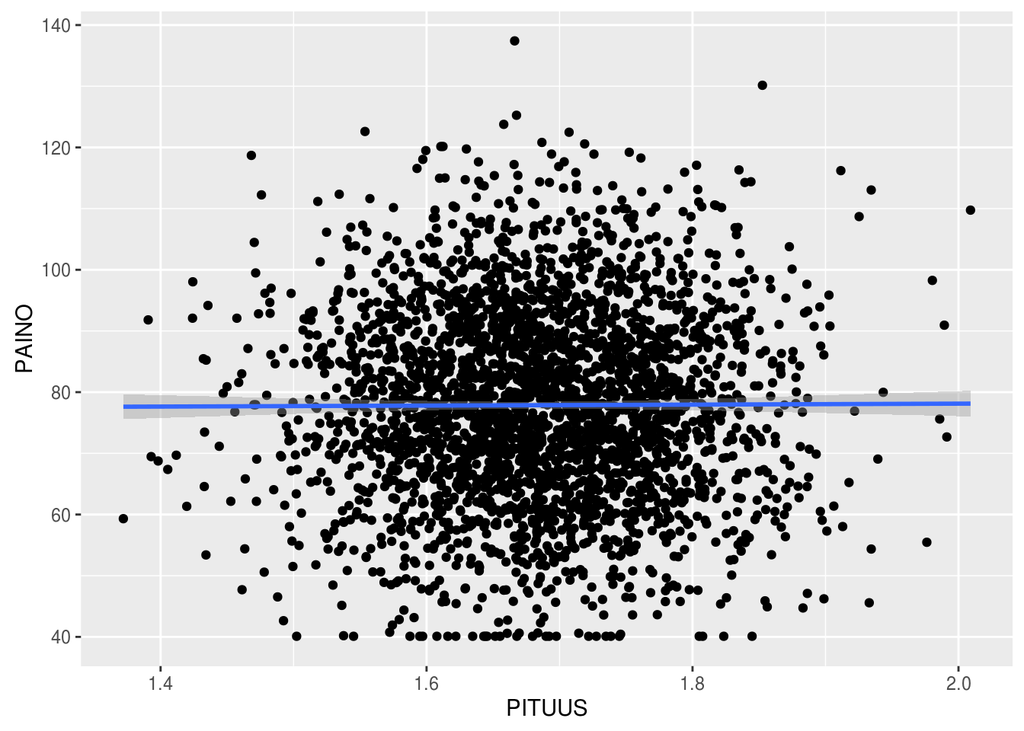

```r
opal.execute(o,'qplot(PITUUS,PAINO, data=D) + geom_smooth(method="lm")')
```

#### Opal Logout

Always free the resources on Opal R server side…